# 621-Final Project

Brian Kreis

May 1, 2018

## Team Members

- Valerie Briot
- Michael D’acampora
- Keith Folsom
- Brian Kreis
- Sharon Morris

# Abstract

# Key words

classifction, UCI credit card dataset, binary logistic, ridge regression, LASSO, Naive Bayes, neural net, class imbalance

# Introduction

Our project team has obtained a data set containing 30,000 observations with each observation representing a credit card customer. Variables included in the data set provide information on that customer’s payment history, outstanding balances as well as demographic information. It is our task to develop a set of classification models to predict the probability that a customer will be in default of their next scheduled payment. The UCI credit card data set contains our default payment response variable, which is binary (0,1), an ID field, and 23 predictor variables. We will break the data set into a training and test set for our evaluation.

The objective is to build multiple classifiction models on the training data to predict the probability that a person will be in default of payment. We will then run analyses to determine which model performed best and apply subsampling techniques to attempt to further improve the model’s accuracy.

This model may be useful for financial institutions who provide revolving credit facilities to determine which customers may need intervention, including where reduction in the size of the outstanding credit facility would be prudent.

# Methodology

Model Description

1. Binary Logistic Regression
2. Logistic Regression using Ridge and Lasso Regularization
3. Decision Trees
4. Naive Bayes
5. Neural Net

# Experimentation and Results

# Dataset

For reproducibility of the results, the data was loaded to and accessed from a Github repository.

# Data Exploration and Statistic Measures

The purpose of the data exploration and statistic measures phase is to understand the data to determine how to process the dataset for modelling.

## Missing and Zero Values

The data does not contain missing values and as such no imputation will be necessary.

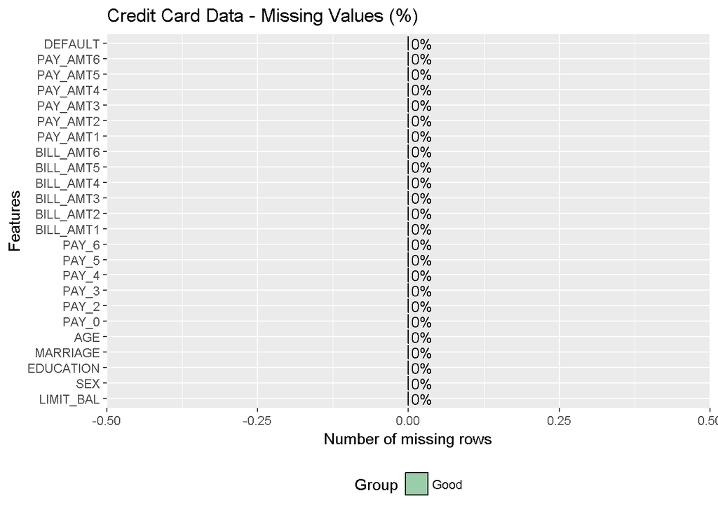

## Variable to Variable Analysis

| Variable | Definition | Type |
| --- | --- | --- |
| LIMIT_BAL | Amount of given credit in NT dollars | Predictor |
| SEX | Gender (1=male, 2=female) | Predictor |
| EDUCATION | (1=graduate school, 2=university, 3=high school, 4=others, 5=unknown, 6=unknown) | Predictor |
| MARRIAGE | Marital status (1=married, 2=single, 3=others) | Predictor |
| AGE | Age in Years | Predictor |
| PAY_0 | Repayment status in September, 2005 | Predictor |
| PAY_2 | Repayment status in August, 2005 | Predictor |
| PAY_3 | Repayment status in July, 2005 | Predictor |
| PAY_4 | Repayment status in June, 2005 | Predictor |
| PAY_5 | Repayment status in May, 2005 | Predictor |
| PAY_6 | Repayment status in April, 2005 | Predictor |
| BILL_AMT1 | Amount of bill statement in September, 2005 | Predictor |
| BILL_AMT2 | Amount of bill statement in August, 2005 | Predictor |
| BILL_AMT3 | Amount of bill statement in July, 2005 | Predictor |
| BILL_AMT4 | Amount of bill statement in June, 2005 | Predictor |
| BILL_AMT5 | Amount of bill statement in May, 2005 | Predictor |
| BILL_AMT6 | Amount of bill statement in April, 2005 | Predictor |
| PAY_AMT1 | Amount of previous payment in September, 2005 | Predictor |
| PAY_AMT2 | Amount of previous payment in August, 2005 | Predictor |
| PAY_AMT3 | Amount of previous payment in July, 2005 | Predictor |
| PAY_AMT4 | Amount of previous payment in June, 2005 | Predictor |
| PAY_AMT5 | Amount of previous payment in May, 2005 | Predictor |
| PAY_AMT6 | Amount of previous payment in April, 2005 | Predictor |
| DEFAULT | Default payment (1=yes, 0=no) | Response |

## Descriptive Statistics

Descriptive statistics was performed for all predictor and response variables to explore the data.

|  | vars | n | mean | sd | median | trimmed | mad | min | max | range | skew | kurtosis | se | IQR | Q0.1 | Q0.25 | Q0.75 | Q0.9 |
| --- | --- | --- | --- | --- | --- | --- | --- | --- | --- | --- | --- | --- | --- | --- | --- | --- | --- | --- |
| LIMIT_BAL | 1 | 30000 | 167484.3226667 | 129747.6615672 | 140000.0 | 151607.4033333 | 133434.0000 | 10000 | 1000000 | 990000 | 0.99276768 | 0.53573780 | 749.098473325 | 190000.00 | 30000.0 | 50000.00 | 240000.00 | 360000.0 |
| SEX | 2 | 30000 | 1.6037333 | 0.4891292 | 2.0 | 1.6296667 | 0.0000 | 1 | 2 | 1 | -0.42414101 | -1.82016507 | 0.002823989 | 1.00 | 1.0 | 1.00 | 2.00 | 2.0 |
| EDUCATION | 3 | 30000 | 1.8531333 | 0.7903487 | 2.0 | 1.7821667 | 1.4826 | 0 | 6 | 6 | 0.97087495 | 2.07773666 | 0.004563080 | 1.00 | 1.0 | 1.00 | 2.00 | 3.0 |
| MARRIAGE | 4 | 30000 | 1.5518667 | 0.5219696 | 2.0 | 1.5536250 | 0.0000 | 0 | 3 | 3 | -0.01873981 | -1.36344964 | 0.003013593 | 1.00 | 1.0 | 1.00 | 2.00 | 2.0 |
| AGE | 5 | 30000 | 35.4855000 | 9.2179041 | 34.0 | 34.6922500 | 8.8956 | 21 | 79 | 58 | 0.73217265 | 0.04389306 | 0.053219594 | 13.00 | 25.0 | 28.00 | 41.00 | 49.0 |
| PAY_0 | 6 | 30000 | -0.0167000 | 1.1238015 | 0.0 | -0.0623750 | 1.4826 | -2 | 8 | 10 | 0.73190173 | 2.71968029 | 0.006488271 | 1.00 | -1.0 | -1.00 | 0.00 | 2.0 |
| PAY_2 | 7 | 30000 | -0.1337667 | 1.1971860 | 0.0 | -0.1985833 | 0.0000 | -2 | 8 | 10 | 0.79048597 | 1.56965135 | 0.006911956 | 1.00 | -2.0 | -1.00 | 0.00 | 2.0 |
| PAY_3 | 8 | 30000 | -0.1662000 | 1.1968676 | 0.0 | -0.2369167 | 0.0000 | -2 | 8 | 10 | 0.84059776 | 2.08354957 | 0.006910118 | 1.00 | -2.0 | -1.00 | 0.00 | 2.0 |
| PAY_4 | 9 | 30000 | -0.2206667 | 1.1691386 | 0.0 | -0.3068750 | 0.0000 | -2 | 8 | 10 | 0.99952945 | 3.49576763 | 0.006750025 | 1.00 | -2.0 | -1.00 | 0.00 | 2.0 |
| PAY_5 | 10 | 30000 | -0.2662000 | 1.1331874 | 0.0 | -0.3596250 | 0.0000 | -2 | 8 | 10 | 1.00809621 | 3.98841731 | 0.006542461 | 1.00 | -2.0 | -1.00 | 0.00 | 0.0 |

[output cut: 14 more lines]

## Analysis of Variables

```
##
##    -2    -1     0     1     2     3     4     5     6     7     8
##  2759  5686 14737  3688  2667   322    76    26    11     9    19
```

## LIMIT_BAL

The majority of customers have lower credit limits, as such the distribution is right skewed

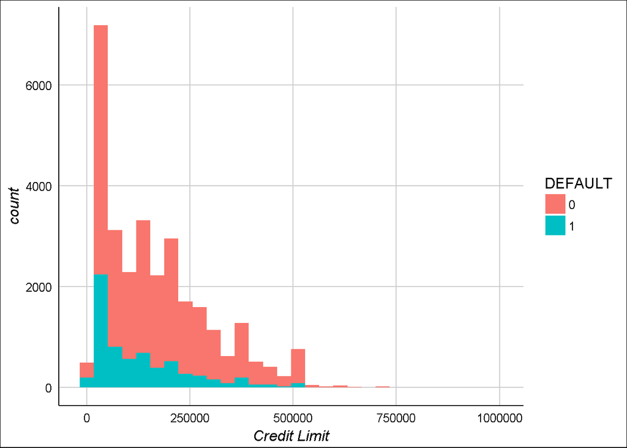

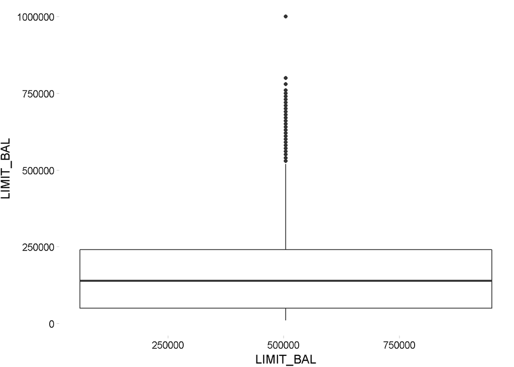

## SEX

The majority of customers are female. This variable can be made into a dummy variable.

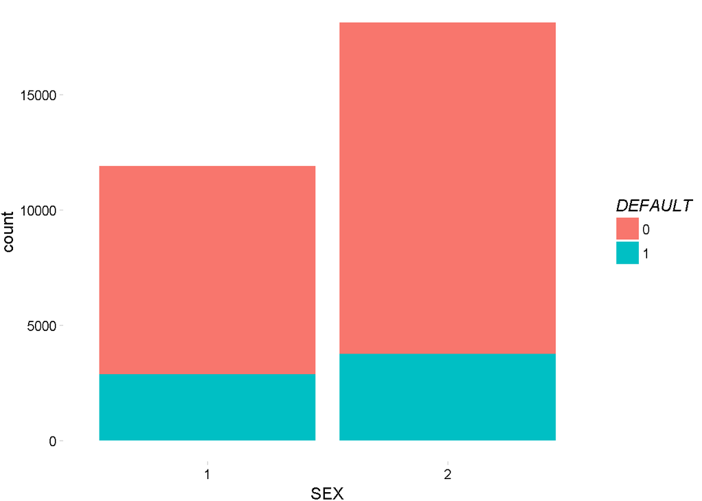

## EDUCATION

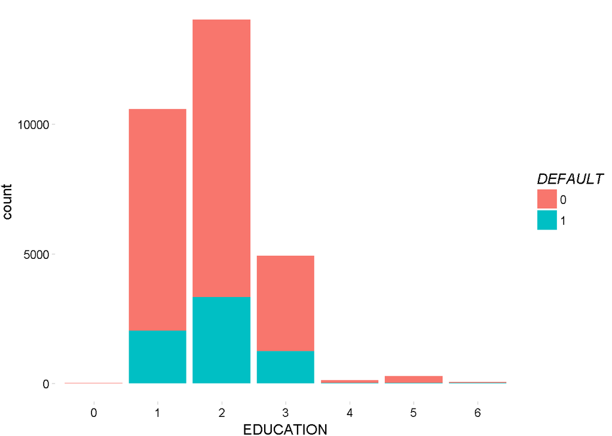

## MARRIAGE

The majority of customers are single and the proportion of default payments appears to be higher for married individual. It appears that there are 0 values here which were not planned. It may be prudent to instead code this as a binary married variable.

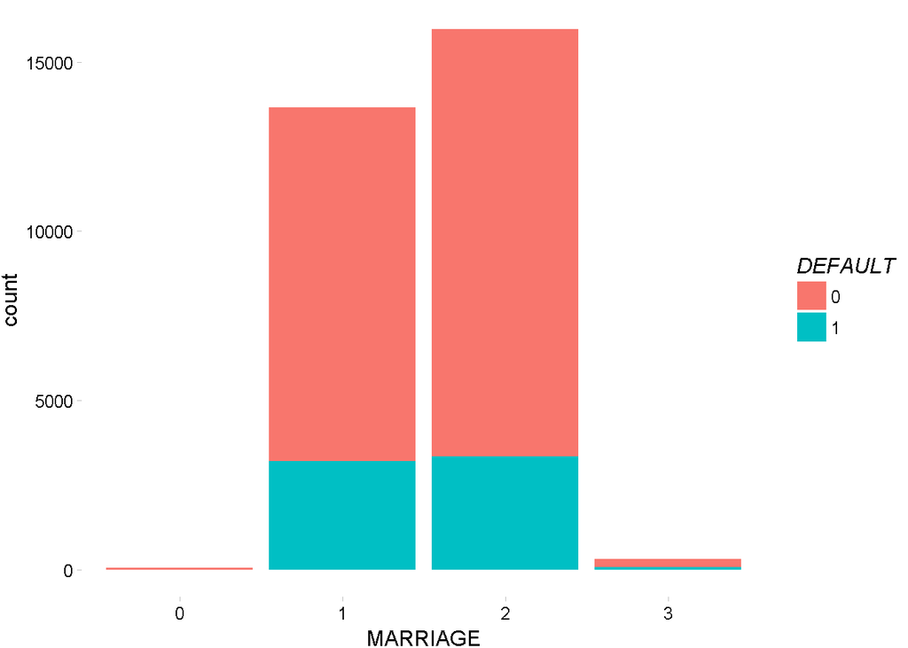

## AGE

The distribution is right skewed. We can see that extremely young customers seem to have a higher proportion of defaults.

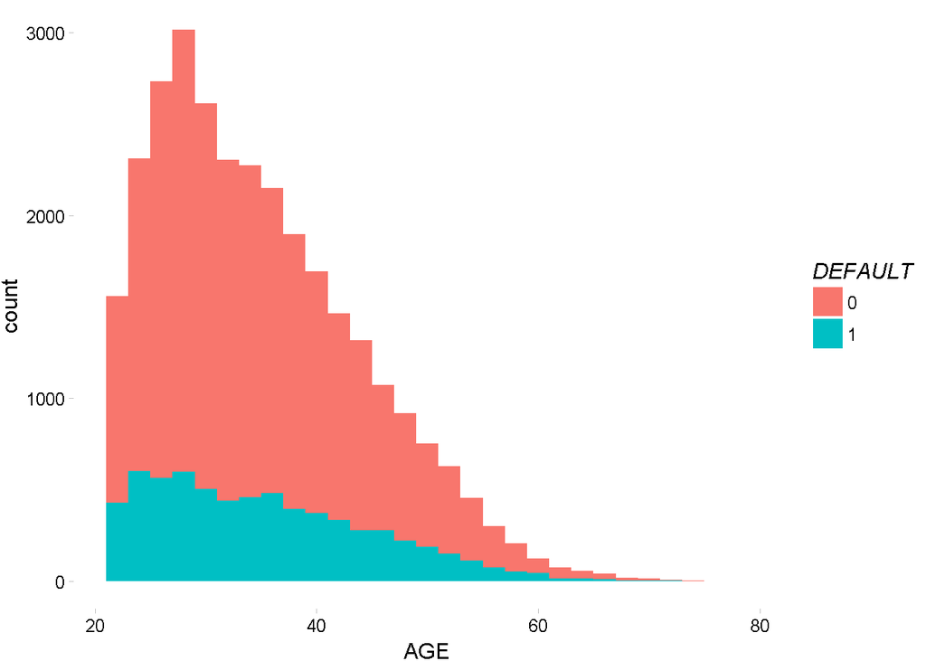

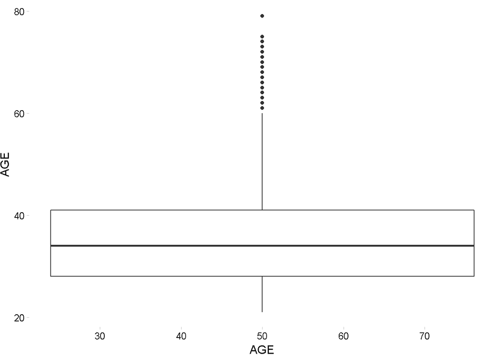

## Repayment Status

The vast majority of clients are on time or ahead of payments. The number of extremely late payments in the latter months are more infrequent. We can presume that this list only contains customers who’s accounts have not yet been charged off, for which we would expect no future payments. Customers with extrmely late repayment statuses 6 months ago have lively already been charged off.

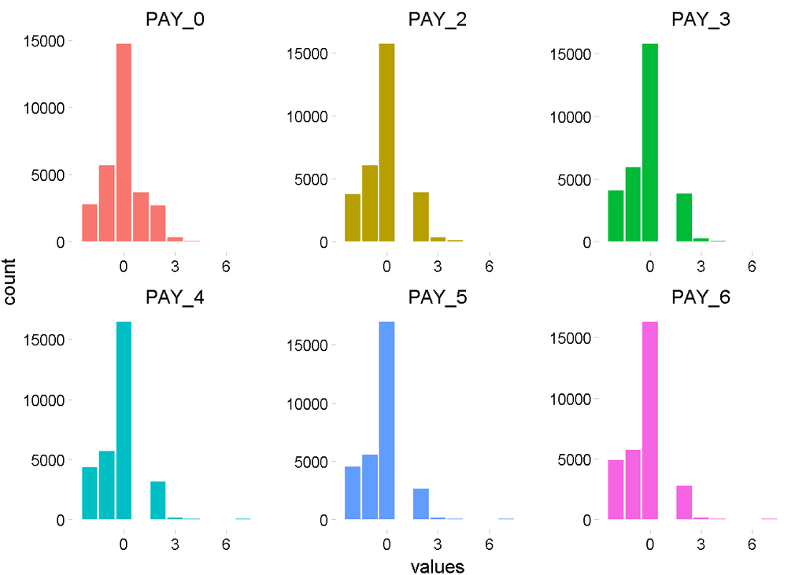

## Bill Amount

We appear to have some negative values for bill amount. This likely represents overpayment by the customer and is not problematic. The distributions are similar.

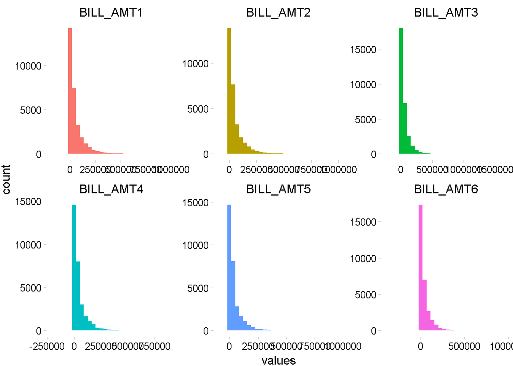

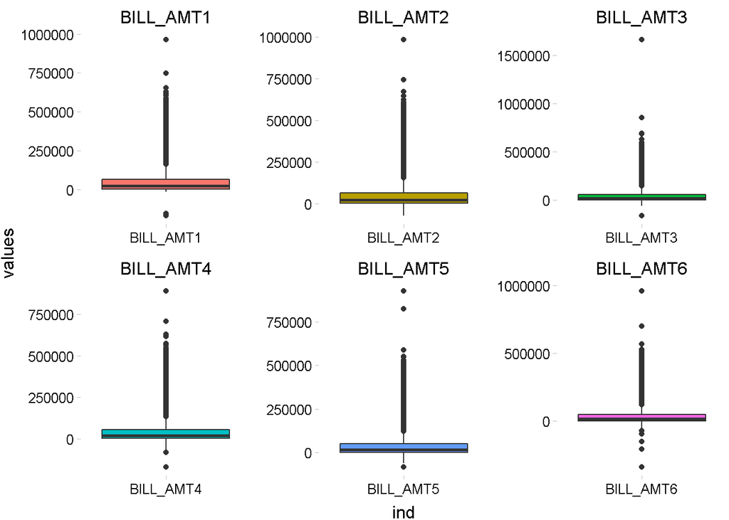

## Pay Amount

The majority of payments are small with some rather large outliers.

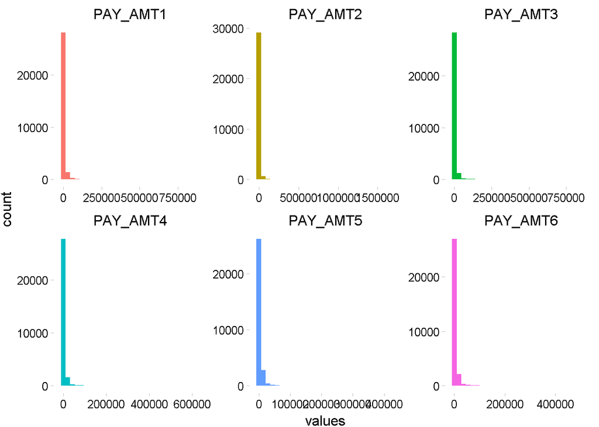

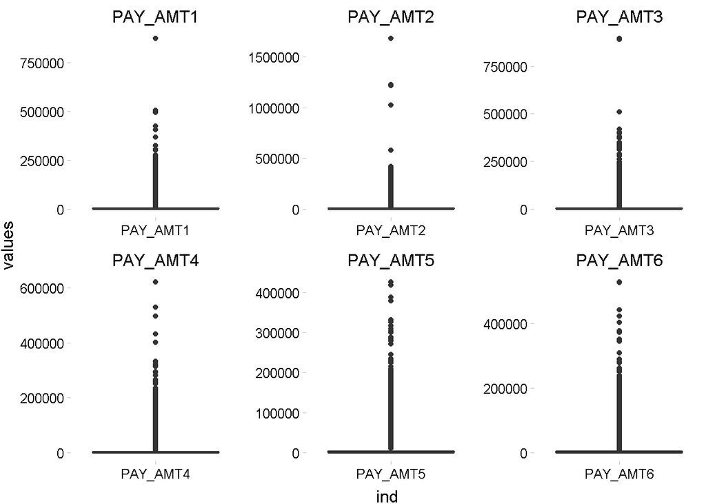

## DEFAULT

As we would expect the majority of customers are not in defualt of their next payment.

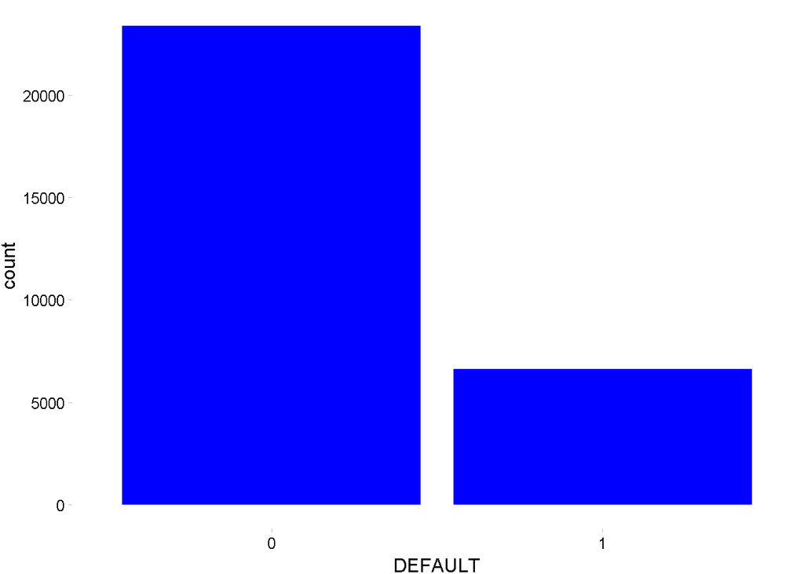

## Recode Predictors

```r
cc_data$MARRIED <- ifelse(cc_data$MARRIAGE==1, 1, 0)

cc_data$MALE <- ifelse(cc_data$SEX==1, 1, 0)

cc_data$EDU_COLLEGE <- ifelse(cc_data$EDUCATION %in% c(1, 2), 1, 0)
cc_data$EDU_ADV_DEGREE <- ifelse(cc_data$EDUCATION == 1, 1, 0)

cc_dataR <- dplyr::select(cc_data, -EDUCATION, -MARRIAGE, -SEX)
```

## Change values to factors

```r
# #Check for data type
sapply(cc_dataR,class)
```

```
##      LIMIT_BAL            AGE          PAY_0          PAY_2          PAY_3
##      "numeric"      "integer"      "integer"      "integer"      "integer"
##          PAY_4          PAY_5          PAY_6      BILL_AMT1      BILL_AMT2
##      "integer"      "integer"      "integer"      "numeric"      "numeric"
##      BILL_AMT3      BILL_AMT4      BILL_AMT5      BILL_AMT6       PAY_AMT1
##      "numeric"      "numeric"      "numeric"      "numeric"      "numeric"
##       PAY_AMT2       PAY_AMT3       PAY_AMT4       PAY_AMT5       PAY_AMT6
##      "numeric"      "numeric"      "numeric"      "numeric"      "numeric"
##        DEFAULT        MARRIED           MALE    EDU_COLLEGE EDU_ADV_DEGREE
##      "integer"      "numeric"      "numeric"      "numeric"      "numeric"
```

```r
#
# #convert categorical to factor variables so that R can create dummy variables
# #ordered
# # vars1 <- c("EDUCATION", "PAY_0", "PAY_2", "PAY_3", "PAY_4", "PAY_5", "PAY_6")
# # cc_data[vars1] <- lapply(cc_data[vars1], ordered)
#
# #unordered
# vars2 <- c("MALE", "MARRIED","EDU_ADV_DEGREE", "EDU_COLLEGE","DEFAULT")
# cc_dataR[vars2] <- lapply(cc_dataR[vars2], factor)
```

## Correlation Analysis

Also as we would expect, the DEFAULT variable is most strongly correlated with the payment status. If a person were to default in one payment period, intuitively we would think that may have a relationship with other periods.

The tables below represent correlation between response and predictor variables.

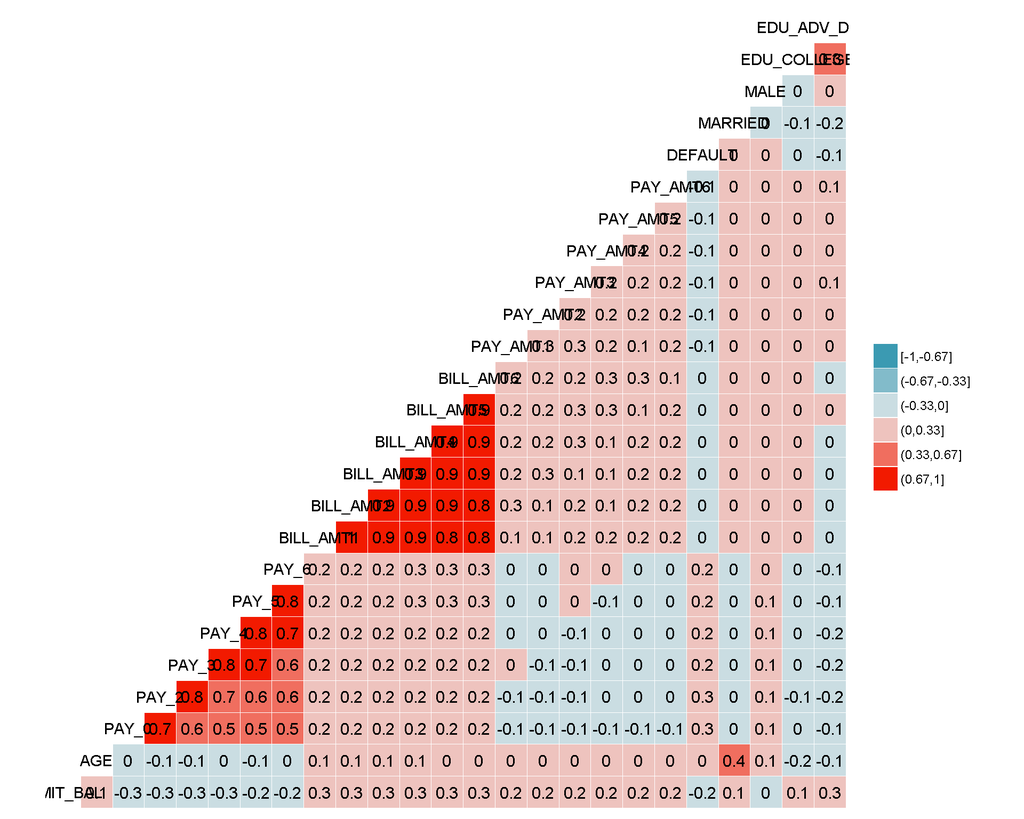

## Diagnostic Model

This is a daignostic model on all of the data. This model performed quite poorly as we would expect with this many correlated variables.

```
##
## Call:
## glm(formula = DEFAULT ~ ., family = binomial(link = "logit"),
##     data = cc_dataR)
##
## Deviance Residuals:
##     Min       1Q   Median       3Q      Max
## -3.1493  -0.7002  -0.5473  -0.2909   3.8872
##
## Coefficients:
##                     Estimate    Std. Error z value             Pr(>|z|)
## (Intercept)    -1.4781163285  0.0763188041 -19.368 < 0.0000000000000002
## LIMIT_BAL      -0.0000007328  0.0000001576  -4.649        0.00000334111
## AGE             0.0061375810  0.0018344878   3.346             0.000821
## PAY_0           0.5769768565  0.0176953903  32.606 < 0.0000000000000002
## PAY_2           0.0828508294  0.0201927565   4.103        0.00004078316
## PAY_3           0.0724596739  0.0226105697   3.205             0.001352
## PAY_4           0.0234991321  0.0250034850   0.940             0.347303
## PAY_5           0.0338535688  0.0268804178   1.259             0.207881
## PAY_6           0.0085164836  0.0221297398   0.385             0.700353
## BILL_AMT1      -0.0000055461  0.0000011371  -4.877        0.00000107588
## BILL_AMT2       0.0000023701  0.0000015068   1.573             0.115746
## BILL_AMT3       0.0000013354  0.0000013232   1.009             0.312870
## BILL_AMT4      -0.0000001760  0.0000013488  -0.130             0.896194
## BILL_AMT5       0.0000006043  0.0000015174   0.398             0.690452
## BILL_AMT6       0.0000004566  0.0000011932   0.383             0.701935
## PAY_AMT1       -0.0000136138  0.0000023032  -5.911        0.00000000341
## PAY_AMT2       -0.0000096106  0.0000020932  -4.591        0.00000440447
## PAY_AMT3       -0.0000027826  0.0000017221  -1.616             0.106131
## PAY_AMT4       -0.0000040402  0.0000017837  -2.265             0.023510
## PAY_AMT5       -0.0000033541  0.0000017740  -1.891             0.058667
## PAY_AMT6       -0.0000020631  0.0000012950  -1.593             0.111150
## MARRIED         0.1891530940  0.0340966677   5.548        0.00000002897
## MALE            0.1130196167  0.0306995848   3.681             0.000232
## EDU_COLLEGE     0.0855064777  0.0418748130   2.042             0.041156
## EDU_ADV_DEGREE  0.0880426779  0.0355666964   2.475             0.013308
##
## (Intercept)    ***
## LIMIT_BAL      ***
## AGE            ***
```

[output cut: 17 more lines]

```
## PAY_AMT6
## MARRIED        ***
## MALE           ***
## EDU_COLLEGE    *
## EDU_ADV_DEGREE *
## ---
## Signif. codes:  0 '***' 0.001 '**' 0.01 '*' 0.05 '.' 0.1 ' ' 1
##
## (Dispersion parameter for binomial family taken to be 1)
##
##     Null deviance: 31705  on 29999  degrees of freedom
## Residual deviance: 27879  on 29975  degrees of freedom
## AIC: 27929
##
## Number of Fisher Scoring iterations: 6
```

```
##      LIMIT_BAL            AGE          PAY_0          PAY_2          PAY_3
##       1.533335       1.353826       1.499550       2.676302       3.300297
##          PAY_4          PAY_5          PAY_6      BILL_AMT1      BILL_AMT2
##       3.886364       4.271201       3.001032      24.246271      40.832111
##      BILL_AMT3      BILL_AMT4      BILL_AMT5      BILL_AMT6       PAY_AMT1
##      29.321315      27.015220      31.379621      18.641790       1.466566
##       PAY_AMT2       PAY_AMT3       PAY_AMT4       PAY_AMT5       PAY_AMT6
##       1.439923       1.463606       1.443428       1.519423       1.114324
##        MARRIED           MALE    EDU_COLLEGE EDU_ADV_DEGREE
##       1.295761       1.025663       1.190452       1.237557
```

## PCA component analysis

As mentioned earlier we have quite a bit of collinearity among predictors, as demonstrated by the screeplot below; the variability accounted for by each component drops sharpely within the first few components.

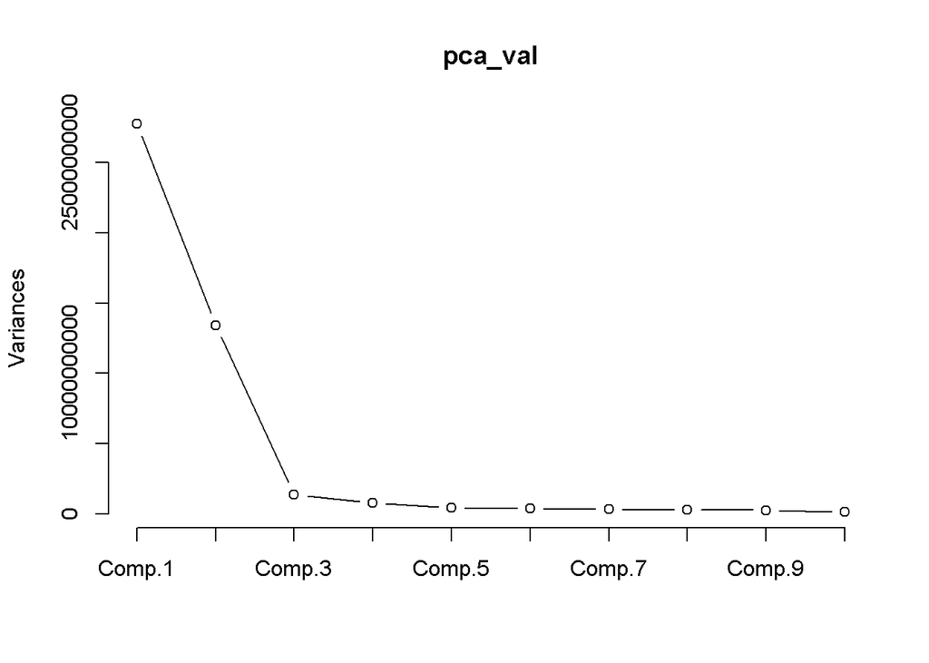

```r
pca_val <- princomp(subset(cc_dataR, select = -DEFAULT))

screeplot(pca_val, type = "lines")
```

We have very high VIF values for all of the BILL_AMT variables. This is not all that surprising as we would not expect the bills to change significantly from month to month for an individual in general. We can create additional variables in attempt to account for the variation that these variables represent and remove the original variables. The following variablese will be created:

- AVG_BILL: The average bill over over the six month period for each customer
- AVG_BILL_TO_LIMIT: The AVG_BILL variable divided by that individual customer’s credit limit
- PAY_TO_BILL: Average Payment made over the 6 months divided by the AVG_BILL
- INC_COUNT: It may also be worthwile to see for how many months the customer’s bill increased from one month to the next. This shows how often a customer is spending more than they payoff each month. If this occurs for five consecutive months it may indicate a worsening financial condition.

It does appear that a relationship is possible between the Average Bill to Limit and the default rate.

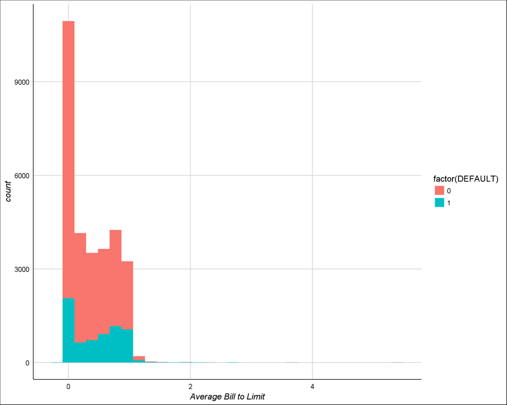

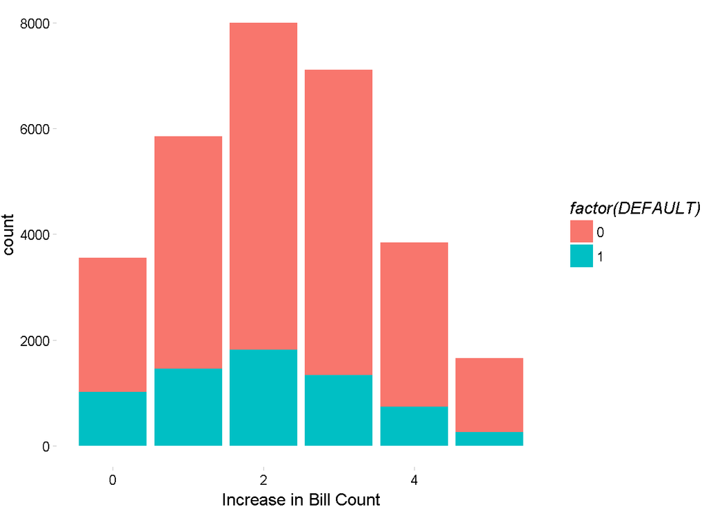

```r
cc_dataR$INC_COUNT = 0
for (i in 1:5) {
  cc_dataR$INC_COUNT <- ifelse(cc_dataR[[paste("BILL_AMT",i, sep = "")]] > cc_dataR[[paste("BILL_AMT",i+1, sep = "")]],
    cc_dataR$INC_COUNT +1, cc_dataR$INC_COUNT +0)
}

ggplot(cc_dataR, aes(x = INC_COUNT, fill = factor(DEFAULT))) +
  geom_bar() +
  labs(x = 'Increase in Bill Count') +
  theme_pander()
```

```r
cc_dataN <- cc_dataR %>%
  dplyr::select(-starts_with('BILL_AMT'))

# rename the response variable DEFAULT to target
cc_dataN$target <- factor(cc_dataR$DEFAULT)
cc_dataN$DEFAULT <- NULL

#colnames(cc_dataN)[15] <- "target"

#Remove rows with infinite values. Only 3 observations
cc_dataN <- cc_dataN[Reduce(`&`, lapply(cc_dataN, function(x) !is.na(x)  & is.finite(x))),]

#Normalize dataset
maxValue <- apply(cc_dataN, 2, max)  #CreditCardnn
minValue <- apply(cc_dataN, 2, min)   #CreditCardnn


smp <- floor(0.70 * nrow(cc_dataN))
set.seed(4784)
train_index <- sample(seq_len(nrow(cc_dataN)), size = smp, replace = FALSE)

# create training and test datasets
train_all <- cc_dataN[train_index, ]
test_all <- cc_dataN[-train_index, ]

## Scale Test and Train for Neural Net

train_nn <- train_all
train_nn$target <- as.integer(train_nn$target)

test_nn <- test_all
test_nn$target <- as.integer(test_nn$target)

#Normalize dataset
maxValueTrain <- apply(train_nn, 2, max)  #CreditCardnn
minValueTrain <- apply(train_nn, 2, min)   #CreditCardnn

maxValueTest <- apply(test_nn, 2, max)  #CreditCardnn
minValueTest <- apply(test_nn, 2, min)   #CreditCardnn

train_nn <- as.data.frame(scale(train_nn, center = minValueTrain, scale = maxValueTrain - minValueTrain))

test_nn <- as.data.frame(scale(test_nn, center = minValueTest, scale = maxValueTest - minValueTest))
```

## Models

### Binary Logistic Regression Model

```r
model2 <- glm(target ~ .,
             data=cc_dataN,
             family = binomial(link="logit"))

#VIF measures are now acceptable
summary(model2)
```

```
##
## Call:
## glm(formula = target ~ ., family = binomial(link = "logit"),
##     data = cc_dataN)
##
## Deviance Residuals:
##     Min       1Q   Median       3Q      Max
## -3.0176  -0.6953  -0.5398  -0.2797   3.5152
##
## Coefficients:
##                        Estimate    Std. Error z value             Pr(>|z|)
## (Intercept)       -1.0340879505  0.0871785317 -11.862 < 0.0000000000000002
## LIMIT_BAL         -0.0000012393  0.0000001995  -6.212       0.000000000523
## AGE                0.0055988803  0.0018452773   3.034             0.002412
## PAY_0              0.5491230523  0.0177725521  30.897 < 0.0000000000000002
## PAY_2              0.1234908761  0.0204762579   6.031       0.000000001630
## PAY_3              0.0842896749  0.0226420693   3.723             0.000197
## PAY_4              0.0336039047  0.0250229910   1.343             0.179297
## PAY_5              0.0432070041  0.0269107607   1.606             0.108369
## PAY_6             -0.0024449598  0.0222109328  -0.110             0.912347
## PAY_AMT1          -0.0000093462  0.0000020535  -4.551       0.000005331137
## PAY_AMT2          -0.0000071096  0.0000018296  -3.886             0.000102
## PAY_AMT3          -0.0000022362  0.0000014507  -1.541             0.123213
## PAY_AMT4          -0.0000033203  0.0000015377  -2.159             0.030828
## PAY_AMT5          -0.0000036517  0.0000015135  -2.413             0.015830
## PAY_AMT6          -0.0000017573  0.0000012457  -1.411             0.158349
## MARRIED            0.1847992742  0.0342433467   5.397       0.000000067898
## MALE               0.1080926485  0.0308040907   3.509             0.000450
## EDU_COLLEGE        0.0823689603  0.0419959914   1.961             0.049838
## EDU_ADV_DEGREE     0.0765372060  0.0356883409   2.145             0.031985
## AVG_BILL          -0.0000001287  0.0000004294  -0.300             0.764403
## AVG_BILL_TO_LIMIT -0.2573878585  0.0730852305  -3.522             0.000429
## PAY_TO_BILL       -0.0003820994  0.0003501892  -1.091             0.275219
## INC_COUNT         -0.1516474906  0.0115247008 -13.158 < 0.0000000000000002
##
## (Intercept)       ***
## LIMIT_BAL         ***
## AGE               **
## PAY_0             ***
## PAY_2             ***
```

[output cut: 13 more lines]

```
## EDU_ADV_DEGREE    *
## AVG_BILL
## AVG_BILL_TO_LIMIT ***
## PAY_TO_BILL
## INC_COUNT         ***
## ---
## Signif. codes:  0 '***' 0.001 '**' 0.01 '*' 0.05 '.' 0.1 ' ' 1
##
## (Dispersion parameter for binomial family taken to be 1)
##
##     Null deviance: 31704  on 29997  degrees of freedom
## Residual deviance: 27721  on 29975  degrees of freedom
## AIC: 27767
##
## Number of Fisher Scoring iterations: 6
```

```r
car::vif(model2)
```

```
##         LIMIT_BAL               AGE             PAY_0             PAY_2
##          2.399901          1.356058          1.510957          2.755513
##             PAY_3             PAY_4             PAY_5             PAY_6
##          3.291086          3.840844          4.222866          2.975699
##          PAY_AMT1          PAY_AMT2          PAY_AMT3          PAY_AMT4
##          1.191943          1.164993          1.126296          1.111271
##          PAY_AMT5          PAY_AMT6           MARRIED              MALE
##          1.093681          1.084530          1.297724          1.025559
##       EDU_COLLEGE    EDU_ADV_DEGREE          AVG_BILL AVG_BILL_TO_LIMIT
##          1.190448          1.235774          2.763182          2.930434
##       PAY_TO_BILL         INC_COUNT
##          1.005226          1.104944
```

### Binary Logistic Regression Model Using Stepwise Variable Selection

```
##
## Call:
## glm(formula = target ~ LIMIT_BAL + AGE + PAY_0 + PAY_2 + PAY_3 +
##     PAY_5 + PAY_AMT1 + PAY_AMT2 + PAY_AMT3 + PAY_AMT4 + PAY_AMT5 +
##     PAY_AMT6 + MARRIED + MALE + EDU_COLLEGE + EDU_ADV_DEGREE +
##     AVG_BILL_TO_LIMIT + PAY_TO_BILL + INC_COUNT, family = binomial(link = "logit"),
##     data = cc_dataN)
##
## Deviance Residuals:
##     Min       1Q   Median       3Q      Max
## -3.0119  -0.6956  -0.5397  -0.2794   3.5184
##
## Coefficients:
##                        Estimate    Std. Error z value             Pr(>|z|)
## (Intercept)       -1.0287416157  0.0839076290 -12.260 < 0.0000000000000002
## LIMIT_BAL         -0.0000012774  0.0000001612  -7.926  0.00000000000000226
## AGE                0.0055944821  0.0018446855   3.033             0.002423
## PAY_0              0.5500387567  0.0177337967  31.016 < 0.0000000000000002
## PAY_2              0.1228642073  0.0204378736   6.012  0.00000000183707449
## PAY_3              0.0971205818  0.0203521517   4.772  0.00000182400425489
## PAY_5              0.0593329265  0.0179426241   3.307             0.000944
## PAY_AMT1          -0.0000094532  0.0000020418  -4.630  0.00000365896971916
## PAY_AMT2          -0.0000068703  0.0000017917  -3.835             0.000126
## PAY_AMT3          -0.0000025451  0.0000014480  -1.758             0.078807
## PAY_AMT4          -0.0000033295  0.0000015211  -2.189             0.028609
## PAY_AMT5          -0.0000036698  0.0000015078  -2.434             0.014936
## PAY_AMT6          -0.0000017793  0.0000012444  -1.430             0.152751
## MARRIED            0.1848379341  0.0342414192   5.398  0.00000006735768129
## MALE               0.1085079695  0.0307899762   3.524             0.000425
## EDU_COLLEGE        0.0820673309  0.0419813432   1.955             0.050600
## EDU_ADV_DEGREE     0.0762382439  0.0356803458   2.137             0.032622
## AVG_BILL_TO_LIMIT -0.2693768879  0.0543383984  -4.957  0.00000071444744115
## PAY_TO_BILL       -0.0003830495  0.0003501388  -1.094             0.273958
## INC_COUNT         -0.1514512870  0.0114714949 -13.202 < 0.0000000000000002
##
## (Intercept)       ***
## LIMIT_BAL         ***
## AGE               **
## PAY_0             ***
## PAY_2             ***
```

[output cut: 10 more lines]

```
## EDU_COLLEGE       .
## EDU_ADV_DEGREE    *
## AVG_BILL_TO_LIMIT ***
## PAY_TO_BILL
## INC_COUNT         ***
## ---
## Signif. codes:  0 '***' 0.001 '**' 0.01 '*' 0.05 '.' 0.1 ' ' 1
##
## (Dispersion parameter for binomial family taken to be 1)
##
##     Null deviance: 31704  on 29997  degrees of freedom
## Residual deviance: 27723  on 29978  degrees of freedom
## AIC: 27763
##
## Number of Fisher Scoring iterations: 6
```

### Ridge and Lasso Regularization Generalized Linear

Ridge regression, also called L2 Regularization, attempts to avoid overfitting

```r
# https://drsimonj.svbtle.com/ridge-regression-with-glmnet
# http://ricardoscr.github.io/how-to-use-ridge-and-lasso-in-r.html

# boruta_output <- Boruta(target ~ ., data=na.omit(train_all), doTrace=2)  # perform Boruta search
#
# #
# boruta_signif <- names(boruta_output$finalDecision[boruta_output$finalDecision %in% c("Confirmed", "Tentative")])
#
# plot(boruta_output, cex.axis=.7, las=2, xlab="", main="Variable Importance")  #


str(train_all)
```

```
## 'data.frame':    20998 obs. of  23 variables:
##  $ LIMIT_BAL        : num  110000 20000 70000 100000 40000 60000 230000 150000 80000 260000 ...
##  $ AGE              : int  29 26 44 47 27 31 41 39 27 51 ...
##  $ PAY_0            : int  2 0 0 0 0 0 0 -1 -2 -1 ...
##  $ PAY_2            : int  0 0 0 0 0 0 0 -1 -2 -1 ...
##  $ PAY_3            : int  0 0 0 0 0 0 0 -1 -2 -1 ...
##  $ PAY_4            : int  0 -2 0 0 0 0 0 0 -2 -1 ...
##  $ PAY_5            : int  0 -2 0 0 0 0 0 -1 -2 -1 ...
##  $ PAY_6            : int  0 -1 0 0 0 0 0 -1 -2 2 ...
##  $ PAY_AMT1         : num  3000 1200 1500 2653 2000 ...
##  $ PAY_AMT2         : num  3000 0 1585 3352 1500 ...
##  $ PAY_AMT3         : num  3000 0 1500 3413 2330 ...
##  $ PAY_AMT4         : num  3500 0 1000 3000 2300 ...
##  $ PAY_AMT5         : num  3000 19125 600 2919 1000 ...
##  $ PAY_AMT6         : num  3000 1000 1500 2944 2078 ...
##  $ MARRIED          : num  0 0 1 1 0 1 1 1 0 0 ...
##  $ MALE             : num  0 1 1 1 1 0 0 0 0 0 ...
##  $ EDU_COLLEGE      : num  1 1 1 1 1 0 1 0 0 1 ...
##  $ EDU_ADV_DEGREE   : num  0 0 0 0 1 0 0 0 0 1 ...
##  $ AVG_BILL         : num  80273 8885 14237 76737 12006 ...
##  $ AVG_BILL_TO_LIMIT: num  0.73 0.444 0.203 0.767 0.3 ...
##  $ PAY_TO_BILL      : num  0.0384 0.4001 0.09 0.0397 0.1557 ...
##  $ INC_COUNT        : num  1 2 3 0 1 4 0 2 3 3 ...
##  $ target           : Factor w/ 2 levels "0","1": 2 1 1 1 2 1 1 1 2 1 ...
```

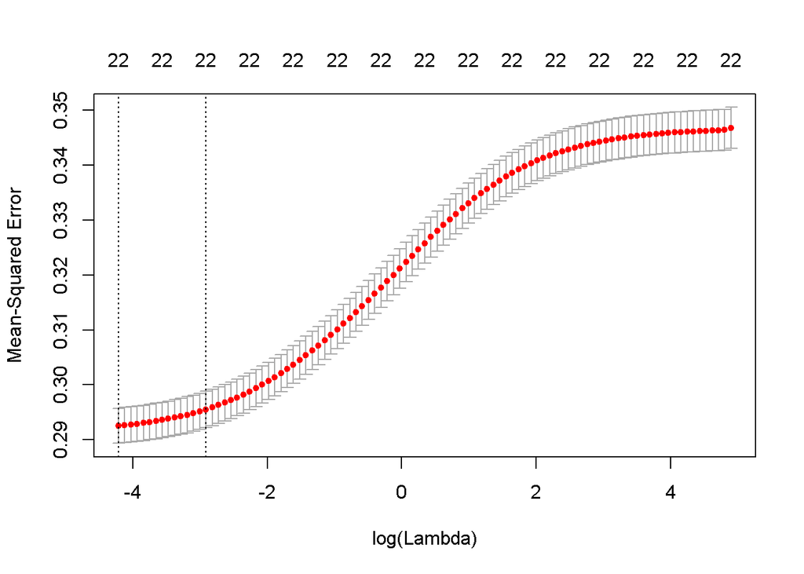

```r
x <- as.matrix(train_all[,-23]) # Removes class
y <- as.double(as.matrix(train_all[, 23])) # Only class


# Fitting the model (Ridge: Alpha = 0)

cv.ridge <- cv.glmnet(x, y, family='binomial', alpha=0,  standardize=TRUE, type.measure='mse')



# Results
plot(cv.ridge)
```

```r
cv.ridge$lambda.min
```

```
## [1] 0.01475955
```

```r
cv.ridge$lambda.1se
```

```
## [1] 0.05429121
```

```r
coef(cv.ridge, s=cv.ridge$lambda.min)
```

```
## 23 x 1 sparse Matrix of class "dgCMatrix"
##                                  1
## (Intercept)       -1.0909361693629
## LIMIT_BAL         -0.0000008401600
## AGE                0.0047800924656
## PAY_0              0.4729775942496
## PAY_2              0.1322022967777
## PAY_3              0.0879255418225
## PAY_4              0.0532826340543
## PAY_5              0.0345085823966
## PAY_6             -0.0014718655072
## PAY_AMT1          -0.0000081608470
## PAY_AMT2          -0.0000046116171
## PAY_AMT3          -0.0000023516995
## PAY_AMT4          -0.0000029667603
## PAY_AMT5          -0.0000029945349
## PAY_AMT6          -0.0000023892241
## MARRIED            0.2084382666834
## MALE               0.0733620448918
## EDU_COLLEGE        0.1040355727552
## EDU_ADV_DEGREE     0.0710947254615
## AVG_BILL          -0.0000007252774
## AVG_BILL_TO_LIMIT -0.1149594016103
## PAY_TO_BILL       -0.0001341710228
## INC_COUNT         -0.1510411511663
```

```r
ridge_model <- cv.ridge$glmnet.fit
summary(ridge_model)
```

```
##            Length Class     Mode
## a0          100   -none-    numeric
## beta       2200   dgCMatrix S4
## df          100   -none-    numeric
## dim           2   -none-    numeric
## lambda      100   -none-    numeric
## dev.ratio   100   -none-    numeric
## nulldev       1   -none-    numeric
## npasses       1   -none-    numeric
## jerr          1   -none-    numeric
## offset        1   -none-    logical
## classnames    2   -none-    character
## call          6   -none-    call
## nobs          1   -none-    numeric
```

```r
#get test data
#x_test <- model.matrix(target~.,test_all)
x_test <- as.matrix(test_all[,-23]) # Removes class
#predict class, type="class"

ridge_prob <- predict(cv.ridge, newx = x_test, s=cv.ridge$lambda.min,type="response")

#translate probabilities to predictions
ridge_predict <- rep(0,nrow(test_all))
ridge_predict[ridge_prob>.5] <- 1
#confusion matrix
table(pred=ridge_predict,true=test_all$target)
```

```
##     true
## pred    0    1
##    0 6885 1533
##    1  166  416
```

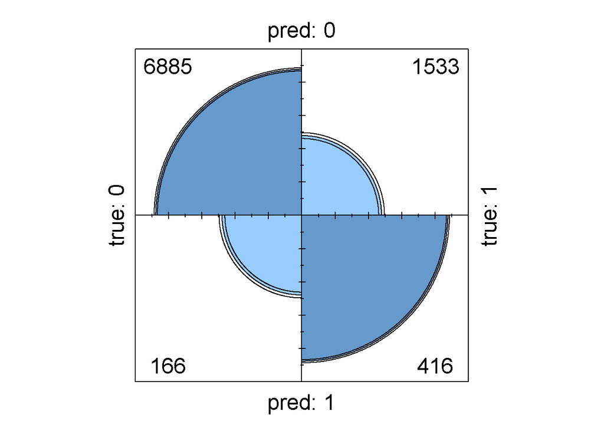

```r
fourfoldplot(table(pred=ridge_predict,true=test_all$target))
```

```r
#accuracy
mean(ridge_predict==test_all$target)
```

```
## [1] 0.8112222
```

### LASSO

Lasso regression, also called L1 Regularization, attempts to avoid overfitting